# Good Reads exploration

## Loading and exploring dataset

```r
library(tidyverse)
library(janitor)
library(lubridate)
library(ggplot2)
library(e1071)
library(modelr)
library(patchwork)
```

```r
books <- read.csv("books.csv") %>%
  clean_names()
```

```r
(books %>%
  dim())
```

```
[1] 11131    12
```

```r
books_cleaned <- books %>%
 drop_na(ratings_count) %>%
  filter(ratings_count != 0) %>%
  filter(!average_rating %in% c(" Jr./Sam B. Warner",
                             " one of the founding members of this Tolkien website)/Verlyn Flieger/Turgon (=David E. Smith)",
                             " Rawles",
                             " Son & Ferguson"
                            ))
```

The dataset has 11,131 rows and 12 variables. We are not concerned with books that have no ratings or books that have a rating count of 0. These have been removed.

A number of entries in the “average rating” category are strings of text. These are also removed, we now have 11,043 rows in the dataset.

The 12 variables in the dataset are:

```r
(books_cleaned %>%
  names())
```

```
 [1] "book_id"            "title"              "authors"            "average_rating"
 [5] "isbn"               "isbn13"             "language_code"      "num_pages"
 [9] "ratings_count"      "text_reviews_count" "publication_date"   "publisher"
```

book_id, isbn and isbn13 are all unique identifiers for each book. We will remove book_id and isbn and use isbn13 as the most appropriate unique identifier.

num_pages has several entries with ‘0’. This questions the reliability of this variable and so it is removed from our dataset.

```r
books_cleaned <- books_cleaned %>%
  select(-c(book_id, isbn, num_pages))
```

```r
(books_cleaned %>%
  glimpse())
```

```
Rows: 11,043
Columns: 9
$ title              <chr> "Harry Potter and the Half-Blood Prince (Harry Potter  #6)", "Harry…
$ authors            <chr> "J.K. Rowling/Mary GrandPré", "J.K. Rowling/Mary GrandPré", "J.K. R…
$ average_rating     <chr> "4.57", "4.49", "4.42", "4.56", "4.78", "3.74", "4.73", "4.38", "4.…
$ isbn13             <chr> "9780439785969", "9780439358071", "9780439554893", "9780439655484",…
$ language_code      <chr> "eng", "eng", "eng", "eng", "eng", "en-US", "eng", "eng", "eng", "e…
$ ratings_count      <int> 2095690, 2153167, 6333, 2339585, 41428, 19, 28242, 3628, 249558, 49…
$ text_reviews_count <int> 27591, 29221, 244, 36325, 164, 1, 808, 254, 4080, 460, 253, 195, 93…
$ publication_date   <chr> "9/16/2006", "9/1/2004", "11/1/2003", "5/1/2004", "9/13/2004", "4/2…
$ publisher          <chr> "Scholastic Inc.", "Scholastic Inc.", "Scholastic", "Scholastic Inc…
```

| title | authors | average_rating | isbn13 | language_code | ratings_count | text_reviews_count | publication_date | publisher |
| --- | --- | --- | --- | --- | --- | --- | --- | --- |
| Harry Potter and the Half-Blood Prince (Harry Potter #6) | J.K. Rowling/Mary GrandPré | 4.57 | 9780439785969 | eng | 2095690 | 27591 | 9/16/2006 | Scholastic Inc. |
| Harry Potter and the Order of the Phoenix (Harry Potter #5) | J.K. Rowling/Mary GrandPré | 4.49 | 9780439358071 | eng | 2153167 | 29221 | 9/1/2004 | Scholastic Inc. |
| Harry Potter and the Chamber of Secrets (Harry Potter #2) | J.K. Rowling | 4.42 | 9780439554893 | eng | 6333 | 244 | 11/1/2003 | Scholastic |
| Harry Potter and the Prisoner of Azkaban (Harry Potter #3) | J.K. Rowling/Mary GrandPré | 4.56 | 9780439655484 | eng | 2339585 | 36325 | 5/1/2004 | Scholastic Inc. |
| Harry Potter Boxed Set Books 1-5 (Harry Potter #1-5) | J.K. Rowling/Mary GrandPré | 4.78 | 9780439682589 | eng | 41428 | 164 | 9/13/2004 | Scholastic |
| Unauthorized Harry Potter Book Seven News: Half-Blood Prince Analysis and Speculation | W. Frederick Zimmerman | 3.74 | 9780976540601 | en-US | 19 | 1 | 4/26/2005 | Nimble Books |
| Harry Potter Collection (Harry Potter #1-6) | J.K. Rowling | 4.73 | 9780439827607 | eng | 28242 | 808 | 9/12/2005 | Scholastic |
| The Ultimate Hitchhiker's Guide: Five Complete Novels and One Story (Hitchhiker's Guide to the Galaxy #1-5) | Douglas Adams | 4.38 | 9780517226957 | eng | 3628 | 254 | 11/1/2005 | Gramercy Books |
| The Ultimate Hitchhiker's Guide to the Galaxy (Hitchhiker's Guide to the Galaxy #1-5) | Douglas Adams | 4.38 | 9780345453747 | eng | 249558 | 4080 | 4/30/2002 | Del Rey Books |
| The Hitchhiker's Guide to the Galaxy (Hitchhiker's Guide to the Galaxy #1) | Douglas Adams | 4.22 | 9781400052929 | eng | 4930 | 460 | 8/3/2004 | Crown |

[output cut: 990 more lines]

This leaves us with 9 variables.

We now tidy these variables to ensure they are of the correct data type for further analysis.

```r
books_cleaned <- books_cleaned %>%
  mutate(average_rating = as.double(average_rating),
         language_code = as.factor(language_code),
         publication_date = mdy(publication_date)) %>%
  drop_na(publication_date)
```

Two entries have incorrect publications dates (31st June and 31st November) given the unreliability of the data, these entries have also been removed.

## Exploring the data: oldest and newest books

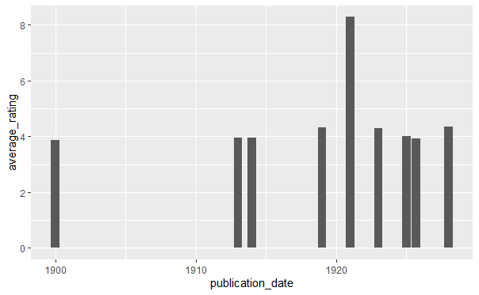

```r
ten_oldest_books <- books_cleaned %>%
  arrange(publication_date) %>%
  head(10)

(plot_ten_oldest <- ten_oldest_books %>%
  ggplot(aes(x = publication_date, y = average_rating)) +
  geom_col())
```

The ten oldest books in the dataset were published between 1900 and 1928. Number of ratings range from 21-332 and average ratings range from 3.91 - 4.35.

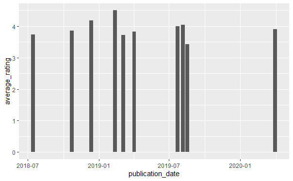

```r
ten_newest_books <- books_cleaned %>%
  arrange(desc(publication_date)) %>%
  head(10)

(plot_ten_newest <- ten_newest_books %>%
  ggplot(aes(x = publication_date, y = average_rating)) +
  geom_col())
```

The 10 newest books in the dataset were published between July 2018 and March 2020. Rating count ranges from 9-56171 and average ratings range from 3.43 to 4.50.

So far the data is showing that there is a narrow range in average rating, regardless of when the book was published or the ratings count.

## Exploring the dataset: average ratings ranges

If we round the average rating and compare the number of each rounded rating we get:

```r
books_cleaned_average <- books_cleaned %>%
  mutate(rounded_rating = round(average_rating), .after = average_rating)


(average_rating_summary <- books_cleaned_average %>%
    group_by(rounded_rating) %>%
    summarise(rounded_rating_count = n()) %>%
    mutate(percentage = round(rounded_rating_count /
             sum(rounded_rating_count) * 100, 2))
)
```

| rounded_rating | rounded_rating_count | percentage |
| --- | --- | --- |
| 1 | 2 | 0.02 |
| 2 | 9 | 0.08 |
| 3 | 689 | 6.24 |
| 4 | 10156 | 91.98 |
| 5 | 185 | 1.68 |

Almost 92% of books have an average rating of 4. So what does it take to get a below average rating (1-3) or an above average rating (5)?

## Exploring the dataset: below average books

```r
(rating_two_or_one <- books_cleaned_average %>%
  filter(rounded_rating <= 2))
```

| title | authors | average_rating | rounded_rating | isbn13 | language_code | ratings_count | text_reviews_count | publication_date | publisher |
| --- | --- | --- | --- | --- | --- | --- | --- | --- | --- |
| Puzzle Pack: The Witch of Blackbird Pond | Mary B. Collins | 1.00 | 1 | 9781583377826 | eng | 2 | 0 | 2005-08-15 | Teacher's Pet Publications Inc. |
| The Boys of the Archangel Raphael: A Youth Confraternity in Florence 1411-1785 | Konrad Eisenbichler | 2.00 | 2 | 9780802043290 | eng | 1 | 0 | 1998-05-30 | University of Toronto Press |
| McDougal Littell Science: Student Edition Grade 6 Earth Science 2006 | McDougal Littell/Douglas W. Carnine | 2.00 | 2 | 9780618615384 | eng | 3 | 0 | 2005-04-12 | McDougal Littel |
| The Halloween Activity Book: Creepy Crawly Hairy Scary Things to Do | Mymi Doinet/Benjamin Chaud | 2.00 | 2 | 9780811832793 | eng | 1 | 1 | 2002-08-01 | Chronicle Books |
| Field Guide to Home Buying in America | Mark LeVine/Michael Pollan/Stephen M. Pollan | 2.50 | 2 | 9780671639617 | eng | 4 | 1 | 1988-05-15 | Touchstone |
| The Two Tocquevilles Father and Son | R.R. Palmer | 2.00 | 2 | 9780691054957 | eng | 1 | 0 | 1987-04-01 | Princeton University Press |
| The Art of Loving by Erich Fromm: A True Story of a Japanese Woman | Lala Okamoto | 1.67 | 2 | 9784990327507 | eng | 3 | 2 | 2006-10-31 | Intercultural Publishing |
| The Earth and Its Peoples: A Global History Volume C: Since 1750 | Richard W. Bulliet/Pamela Kyle Crossley/Steven Hirsch | 2.00 | 2 | 9780618427697 | eng | 1 | 1 | 2004-02-09 | Cengage Learning |
| Citizen Girl | Emma McLaughlin/Nicola Kraus | 2.40 | 2 | 9780743266864 | en-US | 5415 | 577 | 2005-10-04 | Washington Square Press |
| Mandala Sand Art Kit | Walter Foster Creative Team | 1.00 | 1 | 9781560107668 | eng | 1 | 0 | 2004-01-01 | Walter Foster Publishing |

[output cut: 1 more lines]

With the exception of “Citizen Girl” all of the books with a rating of 2 or 1 have a ratings count of <5 . Citizen Girl has a ratings count of 5415.

This suggests that there is a potential pattern in the number of reviews and the overall average rating. This is explored further by looking a the rating count ranges for each of the average score categories.

```r
(rating_count_ranges <- books_cleaned_average %>%
  group_by(rounded_rating) %>%
  summarise(min_review_count = min(ratings_count),
            max_review_count = max(ratings_count))
)
```

| rounded_rating | min_review_count | max_review_count |
| --- | --- | --- |
| 1 | 1 | 2 |
| 2 | 1 | 5415 |
| 3 | 1 | 609586 |
| 4 | 1 | 4597666 |
| 5 | 1 | 2339585 |

```r
NA
NA
```

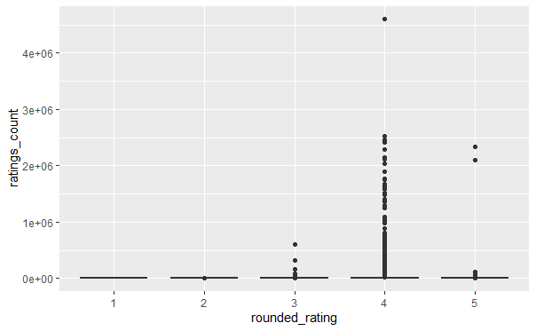

```r
(ratings_boxplot <- books_cleaned_average %>%
  mutate(rounded_rating = as.factor(rounded_rating)) %>%
  ggplot(aes(x = rounded_rating,
             y= ratings_count)) +
  geom_boxplot())
```

Due to the range of results it is impossible to infer anything specific from these boxplots; however, there appears to be a few outliers that are perhaps skewing our data. This leads to the question, is there a pattern to what makes more people read and review a book?

We can break our data down to look at the top 5% most reviewed books.

```r
top_5_percent_ratings_count <- books_cleaned_average %>%
  mutate(top_5_percent_ratings_count =
           percent_rank(ratings_count) > 0.95) %>%
  filter(top_5_percent_ratings_count == TRUE)
```

Summary of the top 5% most reviewed books (552 books):

```r
(top_5_percent_ratings_count %>%
  summary())
```

```
    title             authors          average_rating  rounded_rating     isbn13
 Length:552         Length:552         Min.   :3.130   Min.   :3.000   Length:552
 Class :character   Class :character   1st Qu.:3.877   1st Qu.:4.000   Class :character
 Mode  :character   Mode  :character   Median :4.030   Median :4.000   Mode  :character
                                       Mean   :4.015   Mean   :3.989
                                       3rd Qu.:4.170   3rd Qu.:4.000
                                       Max.   :4.590   Max.   :5.000

 language_code ratings_count     text_reviews_count publication_date      publisher
 eng    :531   Min.   :  61639   Min.   :  109      Min.   :1952-12-01   Length:552
 en-US  : 13   1st Qu.:  84114   1st Qu.: 2356      1st Qu.:2001-06-12   Class :character
 spa    :  4   Median : 128474   Median : 4014      Median :2004-01-30   Mode  :character
 en-GB  :  2   Mean   : 273958   Mean   : 6946      Mean   :2002-12-03
 fre    :  2   3rd Qu.: 248678   3rd Qu.: 7563      3rd Qu.:2006-01-17
 ale    :  0   Max.   :4597666   Max.   :94265      Max.   :2014-07-29
 (Other):  0
 top_5_percent_ratings_count
 Mode:logical
 TRUE:552
```

Perhaps one area to explore is whether there are publishers that get better reviews than others.

```r
(top_5_percent_ratings_count %>%
  distinct(publisher) %>%
  arrange(publisher))
```

| publisher |
| --- |
| Ace |
| Ace Book |
| Ace Books |
| Addison Wesley Publishing Company |
| Albin Michel |
| Alfred A. Knopf |
| Alfred A. Knopf Books for Young Readers |
| Alfred A. Knopf Borzoi Books |
| Algonquin Books |
| Allen & Ulwin |

[output cut: 235 more lines]

It looks like there is inconsistent naming of publishers, or often one publishing house has multiple divisions that they publsih under. This means looking at publishing info will require a lot of tidying and is likely not worth it.

## Exploring the data: publishing languages

Let’s looks at books that have been published in multiple languages

```r
published_more_than_once <- books_cleaned_average %>%
  filter(duplicated(title) | duplicated(title, fromLast = TRUE)) %>%
  arrange(title)

(published_more_than_once %>%
  distinct(title))
```

| title |
| --- |
| 'Salem's Lot |
| 1776 |
| 1984 |
| A Christmas Carol |
| A Clockwork Orange |
| A Confederacy of Dunces |
| A Farewell to Arms |
| A Hard Day's Write: The Stories Behind Every Beatles Song |
| A History of God: The 4 000-Year Quest of Judaism Christianity and Islam |
| A Little Princess |

[output cut: 474 more lines]

How many languages are represented in the books published more than once?

```r
(published_more_than_once %>%
   distinct(language_code))
```

| language_code |
| --- |
| eng |
| en-US |
| spa |
| en-CA |
| en-GB |
| ger |
| fre |
| grc |
| ale |

It looks like 9 langauges, but 4 of these are English. We will group “eng”, “en-CA”, “en-GB” and “en-US” together, to be left with 6 distinct languages: - Aleut - English - French - German - Greek - Spanish

```r
#grouping all versions of English together and calculating mean average rating per book, per language.

published_more_than_once <- published_more_than_once %>%
  mutate(language_code = case_when(
    language_code %in% c("en-CA", "en-GB", "en-US") ~ "eng",
    .default = language_code)
    ) %>%
    group_by(title, language_code) %>%
    summarise(average_rating = mean(average_rating))
```

Use our grouped data we can look at books that have been published in multiple languages:

```r
published_multiple_languages <- published_more_than_once %>%
  filter(duplicated(title) | duplicated(title, fromLast = TRUE)) %>%
  arrange(title)
```

We find that there are 19 books published in multiple languages:

```r
(published_multiple_languages %>%
  distinct(title))
```

| title |
| --- |
| 1984 |
| Artemis Fowl (Artemis Fowl #1) |
| Carrie |
| Fahrenheit 451 |
| Ficciones |
| Galápagos |
| Glamorama |
| Jane Eyre |
| Libra |
| Lincoln |

[output cut: 9 more lines]

Do books do better in different languages, or do they score roughly the same?

```r
(mult_languages_pivot <- published_multiple_languages %>%
  pivot_wider(names_from = language_code, values_from = average_rating))
```

| title | eng | spa | ger | fre | grc | ale |
| --- | --- | --- | --- | --- | --- | --- |
| 1984 | 4.180 | 4.18 | NA | NA | NA | NA |
| Artemis Fowl (Artemis Fowl #1) | 3.840 | 3.84 | 3.84 | NA | NA | NA |
| Carrie | 3.960 | 3.96 | NA | NA | NA | NA |
| Fahrenheit 451 | 3.990 | 3.99 | NA | NA | NA | NA |
| Ficciones | 4.450 | 4.45 | NA | NA | NA | NA |
| Galápagos | 3.880 | NA | NA | 3.88 | NA | NA |
| Glamorama | 3.460 | NA | 3.46 | 3.46 | NA | NA |
| Jane Eyre | 4.108 | NA | 4.12 | NA | NA | NA |
| Libra | 3.990 | NA | NA | 3.99 | NA | NA |
| Lincoln | 4.210 | 4.21 | NA | NA | NA | NA |

[output cut: 9 more lines]

```r
NA
```

```r
#adding colour palette

cbb_palette_language <- c("#56B4E9", "#0072B2","#D55E00", "#E69F00", "darkgreen", "#009E73")
```

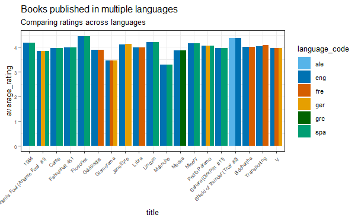

```r
published_multiple_languages %>%
  ggplot(aes(x = title, y = average_rating,
             fill = language_code)) +
  geom_col(position = "dodge") +
  scale_fill_manual(values = cbb_palette_language) +
  theme_bw() +
    labs(title = "Books published in multiple languages",
       subtitle = "Comparing ratings across languages") +
       theme(
     text = element_text(size = 10),
     axis.text.x = element_text(size = 6,
                                angle = 45,
                                hjust = 1),
     axis.text.y = element_text(size = 6))
```

Jane Eyre averaged slightly lower in English than in German (4.11 to 4.12).

Trainspotting scored slightly lower in English than in French (4.03 to 4.09).

Let’s add the variations on English back in to see if this changes anything:

```r
published_more_than_once_english <- books_cleaned_average %>%
  filter(duplicated(title) | duplicated(title, fromLast = TRUE)) %>%
  arrange(title) %>%
  group_by(title, language_code) %>%
  summarise(average_rating = mean(average_rating)) %>%
  filter(duplicated(title) | duplicated(title, fromLast = TRUE))
```

```r
(mult_languages_pivot_eng <- published_more_than_once_english %>%
  pivot_wider(names_from = language_code, values_from = average_rating))
```

| title | en-US | eng | spa | en-CA | en-GB | ger | fre | grc | ale |
| --- | --- | --- | --- | --- | --- | --- | --- | --- | --- |
| 'Salem's Lot | 4.02 | 4.058333 | NA | NA | NA | NA | NA | NA | NA |
| 1984 | NA | 4.180000 | 4.18 | NA | NA | NA | NA | NA | NA |
| A Christmas Carol | NA | 4.050000 | NA | 4.05 | NA | NA | NA | NA | NA |
| A Little Princess | NA | 4.180000 | NA | NA | 4.20 | NA | NA | NA | NA |
| A Midsummer Night's Dream | 3.94 | 3.940000 | NA | NA | NA | NA | NA | NA | NA |
| A Passage to India | NA | 3.680000 | NA | NA | 3.68 | NA | NA | NA | NA |
| A Random Walk Down Wall Street | 4.10 | 4.100000 | NA | NA | NA | NA | NA | NA | NA |
| A Room of One's Own | 4.14 | 4.140000 | NA | NA | NA | NA | NA | NA | NA |
| A Streetcar Named Desire | 3.98 | 3.980000 | NA | NA | NA | NA | NA | NA | NA |
| A Tale of Two Cities | 3.84 | 3.840000 | NA | NA | 3.84 | NA | NA | NA | NA |

[output cut: 146 more lines]

This hasn’t been looked at in any details yet. It appears that there are minor variations, but nothing that stands out. It might be worth exploring this further. This data could perhaps let publishers and authors get an idea of what languages might be worth publishing in. Or if readers of of variation of English tend to give better reviews.

# Changing tact

Looking at at the average rating per language for all books

```r
(language_avg <- books_cleaned_average %>%
  group_by(language_code) %>%
  summarise(count = n(), mean_avg = mean(average_rating))
)
```

| language_code | count | mean_avg |
| --- | --- | --- |
| ale | 1 | 4.360000 |
| ara | 1 | 3.550000 |
| en-CA | 7 | 4.025714 |
| en-GB | 214 | 3.923411 |
| en-US | 1408 | 3.914659 |
| eng | 8844 | 3.944913 |
| enm | 3 | 3.873333 |
| fre | 139 | 3.971367 |
| ger | 96 | 3.946458 |
| gla | 1 | 4.470000 |

[output cut: 16 more lines]

Need to removed langauges with fewest review numbers. Suggest >20.

```r
#looking at the average review score for languages that appear >20
(language_avg_20 <- books_cleaned_average %>%
  group_by(language_code) %>%
  filter(n() > 20) %>%
  summarise(count = n(), mean_avg = mean(average_rating))
)
```

| language_code | count | mean_avg |
| --- | --- | --- |
| en-GB | 214 | 3.923411 |
| en-US | 1408 | 3.914659 |
| eng | 8844 | 3.944913 |
| fre | 139 | 3.971367 |
| ger | 96 | 3.946458 |
| jpn | 45 | 4.273333 |
| spa | 212 | 3.923726 |

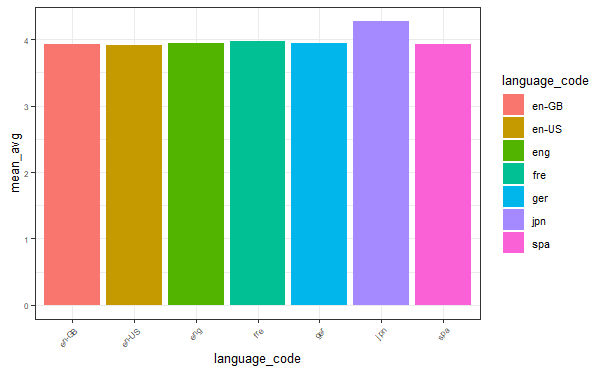

```r
language_avg_20 %>%
  ggplot(aes(x = language_code, y = mean_avg, fill = language_code)) +
  geom_col() +
  theme_bw() +
       theme(
     text = element_text(size = 10),
     axis.text.x = element_text(size = 6,
                                angle = 45,
                                hjust = 1),
     axis.text.y = element_text(size = 6))
```

What is the average across all books?

```r
(avg_all_books <- books_cleaned_average %>%
  summarise(mean_avg = mean(average_rating)))
```

| mean_avg |
| --- |
| 3.943213 |

```r
(language_avg_20_above_below <- language_avg_20 %>%
   mutate(mean = 3.943) %>%
   mutate(above_or_below = if_else(mean_avg > mean, "above", "below"))
)
```

| language_code | count | mean_avg | mean | above_or_below |
| --- | --- | --- | --- | --- |
| en-GB | 214 | 3.923411 | 3.943 | below |
| en-US | 1408 | 3.914659 | 3.943 | below |
| eng | 8844 | 3.944913 | 3.943 | above |
| fre | 139 | 3.971367 | 3.943 | above |
| ger | 96 | 3.946458 | 3.943 | above |
| jpn | 45 | 4.273333 | 3.943 | above |
| spa | 212 | 3.923726 | 3.943 | below |

```r
above_below_palette <- c("darkgreen", "darkred")
```

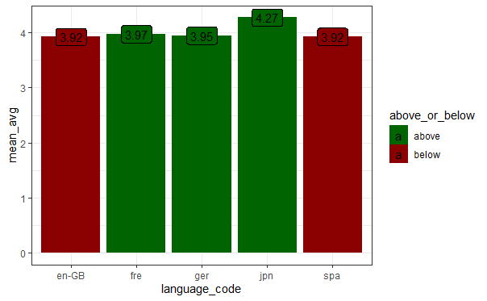

```r
language_avg_20_above_below %>%
  filter(language_code != c("eng", "en-US")) %>%
  ggplot(aes(x = language_code, y = mean_avg, fill = above_or_below)) +
  geom_col() +
  scale_fill_manual(values = above_below_palette) +
  geom_label(aes(label = round((mean_avg), 2))) +
  theme_bw()
```

Maybe there is something here? Take out en-US and eng to leave us with a more comfortable range of review numbers?

# Number of pages vs ratings count

```r
#reproducing cleaned data, this time keeping num_pages

books_cleaned_v2 <- books %>%
  drop_na(ratings_count) %>%
  filter(ratings_count != 0) %>%
  filter(!average_rating %in% c(" Jr./Sam B. Warner",
                             " one of the founding members of this Tolkien website)/Verlyn Flieger/Turgon (=David E. Smith)",
                             " Rawles",
                             " Son & Ferguson"
                            )) %>%
  select(-c(book_id, isbn)) %>%
  mutate(num_pages = as.integer(num_pages),
         ratings_count = as.integer(ratings_count)) %>%
  mutate(average_rating = as.double(average_rating),
         language_code = as.factor(language_code),
         publication_date = mdy(publication_date)) %>%
  drop_na(publication_date) %>%
  mutate(publication_year = year(publication_date)) %>%
  arrange(num_pages)
```

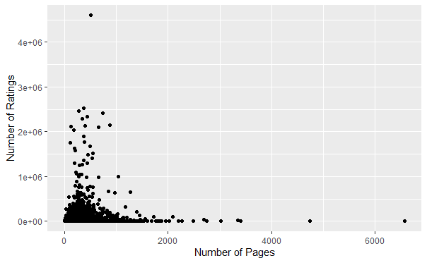

```r
books_cleaned_v2 %>%
ggplot(aes(x = num_pages, y = ratings_count)) +
  geom_point() +
  labs(x = "Number of Pages", y = "Number of Ratings")
```

```r
# how many books have <100 pages?

books_cleaned_v2 %>%
  filter(num_pages <100)
```

| title | authors | average_rating | isbn13 | language_code | num_pages | ratings_count | text_reviews_count | publication_date | publisher | publication_year |
| --- | --- | --- | --- | --- | --- | --- | --- | --- | --- | --- |
| The 5 Love Languages / The 5 Love Languages Journal | Gary Chapman | 4.70 | 9780802415318 | eng | 0 | 22 | 4 | 2005-01-01 | Moody Publishers | 2005 |
| The Tragedy of Pudd'nhead Wilson | Mark Twain/Michael Prichard | 3.79 | 9781400150687 | eng | 0 | 3 | 0 | 2003-01-01 | Tantor Media | 2003 |
| Murder by Moonlight & Other Mysteries (New Adventures of Sherlock Holmes 19-24) | NOT A BOOK | 4.00 | 9780743564670 | eng | 0 | 7 | 2 | 2006-10-03 | Simon Schuster Audio | 2006 |
| The Unfortunate Tobacconist & Other Mysteries (Sherlock Holmes 1-6) | NOT A BOOK | 3.50 | 9780743533959 | eng | 0 | 12 | 1 | 2003-10-01 | Simon & Schuster Audio | 2003 |
| The Da Vinci Code (Robert Langdon #2) | Dan Brown/Paul Michael | 3.84 | 9780739339787 | eng | 0 | 91 | 16 | 2006-03-28 | Random House Audio | 2006 |
| The Summons / The Brethren | John Grisham/Michael Beck/Frank Muller | 3.99 | 9780739342770 | eng | 0 | 241 | 9 | 2006-10-10 | Random House Audio | 2006 |
| The Patricia Cornwell CD Audio Treasury: All That Remains / Cruel & Unusual (Kay Scarpetta #3 #4) | Patricia Cornwell/Kate Burton | 4.16 | 9780060791216 | eng | 0 | 202 | 1 | 2005-07-26 | HarperAudio | 2005 |
| Like Water for Chocolate | Laura Esquivel/Yareli Arizmendi | 3.95 | 9780739334195 | eng | 0 | 121 | 33 | 2006-05-02 | Random House Audio | 2006 |
| A Study Guide to Gabriel Garcia Marquez' One Hundred Years of Solitude | Gabriel García Márquez/Brenda K. Marshall/F. Murray Abraham | 4.11 | 9781570421129 | eng | 0 | 75 | 2 | 2006-04-01 | Warner Adult | 2006 |
| The Michael Crichton Collection: Airframe / The Lost World / Timeline | Michael Crichton/Stephen Lang/Anthony Heald/Blair Brown | 4.16 | 9780739340332 | en-GB | 0 | 267 | 7 | 2006-08-29 | Random House Audio | 2006 |

[output cut: 990 more lines]

```r
books_cleaned_v2 %>%
  filter(num_pages == 0)
```

| title | authors | average_rating | isbn13 | language_code | num_pages | ratings_count | text_reviews_count | publication_date | publisher | publication_year |
| --- | --- | --- | --- | --- | --- | --- | --- | --- | --- | --- |
| The 5 Love Languages / The 5 Love Languages Journal | Gary Chapman | 4.70 | 9780802415318 | eng | 0 | 22 | 4 | 2005-01-01 | Moody Publishers | 2005 |
| The Tragedy of Pudd'nhead Wilson | Mark Twain/Michael Prichard | 3.79 | 9781400150687 | eng | 0 | 3 | 0 | 2003-01-01 | Tantor Media | 2003 |
| Murder by Moonlight & Other Mysteries (New Adventures of Sherlock Holmes 19-24) | NOT A BOOK | 4.00 | 9780743564670 | eng | 0 | 7 | 2 | 2006-10-03 | Simon Schuster Audio | 2006 |
| The Unfortunate Tobacconist & Other Mysteries (Sherlock Holmes 1-6) | NOT A BOOK | 3.50 | 9780743533959 | eng | 0 | 12 | 1 | 2003-10-01 | Simon & Schuster Audio | 2003 |
| The Da Vinci Code (Robert Langdon #2) | Dan Brown/Paul Michael | 3.84 | 9780739339787 | eng | 0 | 91 | 16 | 2006-03-28 | Random House Audio | 2006 |
| The Summons / The Brethren | John Grisham/Michael Beck/Frank Muller | 3.99 | 9780739342770 | eng | 0 | 241 | 9 | 2006-10-10 | Random House Audio | 2006 |
| The Patricia Cornwell CD Audio Treasury: All That Remains / Cruel & Unusual (Kay Scarpetta #3 #4) | Patricia Cornwell/Kate Burton | 4.16 | 9780060791216 | eng | 0 | 202 | 1 | 2005-07-26 | HarperAudio | 2005 |
| Like Water for Chocolate | Laura Esquivel/Yareli Arizmendi | 3.95 | 9780739334195 | eng | 0 | 121 | 33 | 2006-05-02 | Random House Audio | 2006 |
| A Study Guide to Gabriel Garcia Marquez' One Hundred Years of Solitude | Gabriel García Márquez/Brenda K. Marshall/F. Murray Abraham | 4.11 | 9781570421129 | eng | 0 | 75 | 2 | 2006-04-01 | Warner Adult | 2006 |
| The Michael Crichton Collection: Airframe / The Lost World / Timeline | Michael Crichton/Stephen Lang/Anthony Heald/Blair Brown | 4.16 | 9780739340332 | en-GB | 0 | 267 | 7 | 2006-08-29 | Random House Audio | 2006 |

[output cut: 65 more lines]

```r
books_cleaned_v2 %>%
  filter(num_pages <10,
         num_pages > 0)
```

| title | authors | average_rating | isbn13 | language_code | num_pages | ratings_count | text_reviews_count | publication_date | publisher | publication_year |
| --- | --- | --- | --- | --- | --- | --- | --- | --- | --- | --- |
| Essential Welty: Why I Live at the P.O. A Memory Powerhouse and Petrified Man | Eudora Welty | 3.94 | 9780061124198 | eng | 1 | 92 | 28 | 2006-06-27 | Caedmon | 2006 |
| The Return of the King (The Lord of the Rings #3) | Brian Sibley/J.R.R. Tolkien | 4.35 | 9780563536598 | eng | 1 | 17 | 3 | 2002-03-04 | BBC Audiobooks Ltd | 2002 |
| Lobsters | Charles Stross/Shandra Marie/Jared Doreck | 3.83 | 9781884612466 | eng | 1 | 158 | 5 | 2005-08-11 | AudioText | 2005 |
| Antibodies | Charles Stross/Shandra Marie/Jared Doreck | 3.46 | 9781884612473 | eng | 1 | 67 | 4 | 2005-08-11 | AudioText | 2005 |
| Meditations for Manifesting: Morning and Evening Meditations to Literally Create Your Heart's Desire | Wayne W. Dyer | 4.02 | 9781561703159 | eng | 1 | 338 | 12 | 1995-06-01 | Hay House | 1995 |
| The Best American Mystery Stories 2003 | Michael Connelly/Otto Penzler | 3.60 | 9780618390724 | eng | 1 | 5 | 2 | 2003-11-04 | Mariner Books | 2003 |
| The Neil Gaiman Audio Collection | Neil Gaiman | 4.24 | 9780060732981 | eng | 1 | 1666 | 208 | 2004-08-31 | HarperFestival | 2004 |
| LT's Theory of Pets | Stephen King | 3.69 | 9780743520058 | eng | 1 | 2824 | 140 | 2001-08-01 | Simon Schuster Audio | 2001 |
| There Was a Cold Lady Who Swallowed Some Snow! | Lucille Colandro/Jared Lee/Skip Hinnant | 3.85 | 9780439895569 | eng | 1 | 14 | 1 | 2006-08-13 | Scholastic Audio Books | 2006 |
| Matilda | Roald Dahl/Rula Lenska/Sian Thomas/Christopher Timothy | 4.31 | 9780141805627 | eng | 1 | 6 | 0 | 2005-03-03 | Puffin Audiobooks | 2005 |

[output cut: 106 more lines]

```r
NA
```

1,010 books have <100 pages, 75 of these have a page count of 0 and 116 have a page count of between 1 & 9. Given the unlikelihood of this many books being this short, it is clear that there are errors in this variable.

There is no known appropriate number for fewest pages a book may have. To try to eliminate any incorrect data, we remove the lowest 5% of num_pages.

```r
# checking books with >1000 pages

books_cleaned_v2 %>%
  filter(num_pages >1000)
```

| title | authors | average_rating | isbn13 | language_code | num_pages | ratings_count | text_reviews_count | publication_date | publisher | publication_year |
| --- | --- | --- | --- | --- | --- | --- | --- | --- | --- | --- |
| The J.R.R. Tolkien Companion and Guide Volume 1: Chronology | Christina Scull/Wayne G. Hammond | 4.51 | 9780618391028 | eng | 1002 | 40 | 2 | 2006-11-02 | Houghton Mifflin Harcourt | 2006 |
| Don Quixote: The Ormsby Translation Revised Backgrounds and Sources Criticism | Miguel de Cervantes Saavedra/John Ormsby | 3.87 | 9780393090185 | eng | 1003 | 56 | 9 | 1980-11-01 | W. W. Norton & Company | 1980 |
| The Shadow Rising (The Wheel of Time #4) | Robert Jordan | 4.24 | 9780812513738 | eng | 1007 | 148074 | 2471 | 1993-10-15 | Tom Doherty Tor Fantasy | 1993 |
| A Robin McKinley Collection: Spindle's End The Hero and the Crown and The Blue Sword (Folktales #1-3) | Robin McKinley | 4.39 | 9780142302330 | eng | 1008 | 527 | 12 | 2002-09-16 | Puffin | 2002 |
| The Major Works | John Milton/Jonathan Goldberg/Stephen Orgel | 4.24 | 9780192804099 | eng | 1008 | 285 | 12 | 2003-04-03 | Oxford University Press | 2003 |
| Shakespeare After All | Marjorie Garber | 4.38 | 9780385722148 | eng | 1008 | 852 | 62 | 2005-09-20 | Anchor Books | 2005 |
| PHP and MySQL Web Development (Developer's Library) | Luke Welling/Laura Thomson | 3.96 | 0752063326725 | en-US | 1008 | 590 | 31 | 2004-10-01 | Sams | 2004 |
| Judas Unchained (Commonwealth Saga #2) | Peter F. Hamilton | 4.31 | 9780345461674 | en-US | 1008 | 738 | 68 | 2007-03-27 | Del Rey | 2007 |
| The Dark Descent | David G. Hartwell/Clive Barker/Ray Bradbury/John Collier/Shirley Jackson/Stephen King/Joyce Carol Oates | 4.25 | 9780312862176 | eng | 1011 | 1991 | 65 | 1997-01-15 | Tor Books | 1997 |
| Lord of Chaos (The Wheel of Time #6) | Robert Jordan | 4.13 | 9780812513752 | eng | 1011 | 109234 | 1962 | 1995-11-15 | Tor Books | 1995 |

[output cut: 205 more lines]

```r
NA
```

```r
# Removing the bottom and top 5% of page count
num_rows <- nrow(books_cleaned_v2)
bottom_percentage <- 0.05
top_percentage <- 0.95

bottom_rows_to_remove <- round(num_rows * bottom_percentage)
top_rows_to_remove <- round(num_rows * (1 - top_percentage))

# Remove the bottom and top rows
trimmed_books_v1 <- books_cleaned_v2[(bottom_rows_to_remove + 1):(num_rows - top_rows_to_remove), , drop = FALSE]
```

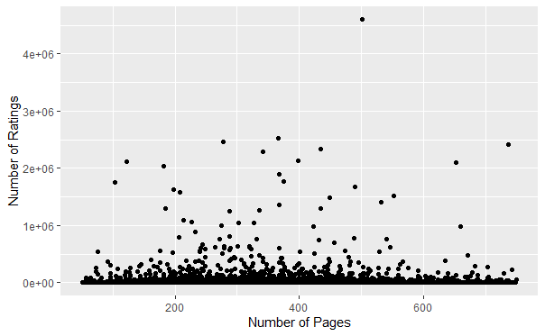

```r
trimmed_books_v1 %>%
  ggplot(aes(x = num_pages, y = ratings_count)) +
  geom_point() +
  labs(x = "Number of Pages", y = "Number of Ratings")
```

```r
trimmed_books_v2 <- trimmed_books_v1 %>%
  arrange(ratings_count)
```

```r
# Removing the bottom and top 5% of ratings count
num_rows <- nrow(trimmed_books_v2)
bottom <- 0.05
top <- 0.95

bottom_remove <- round(num_rows * bottom)
top_remove <- round(num_rows * (1 - top))

# Remove the bottom and top rows
trimmed_books_v2 <- trimmed_books_v2[(bottom_remove + 1):(num_rows - top_remove), , drop = FALSE]
```

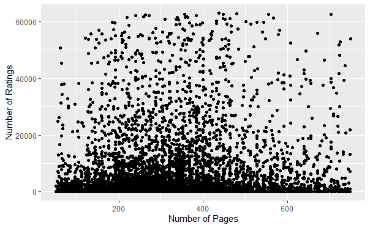

```r
trimmed_books_v2 %>%
  ggplot(aes(x = num_pages, y = ratings_count)) +
  geom_point() +
  labs(x = "Number of Pages", y = "Number of Ratings")
```

```r
model <- lm(ratings_count ~ num_pages, data = trimmed_books_v2)
summary(model)
```

```
Call:
lm(formula = ratings_count ~ num_pages, data = trimmed_books_v2)

Residuals:
   Min     1Q Median     3Q    Max
 -7853  -4784  -3817   -632  57552

Coefficients:
             Estimate Std. Error t value Pr(>|t|)
(Intercept) 3146.4823   261.1887  12.047   <2e-16 ***
num_pages      6.3464     0.7494   8.469   <2e-16 ***
---
Signif. codes:  0 ‘***’ 0.001 ‘**’ 0.01 ‘*’ 0.05 ‘.’ 0.1 ‘ ’ 1

Residual standard error: 10340 on 8941 degrees of freedom
Multiple R-squared:  0.007957,  Adjusted R-squared:  0.007846
F-statistic: 71.72 on 1 and 8941 DF,  p-value: < 2.2e-16
```

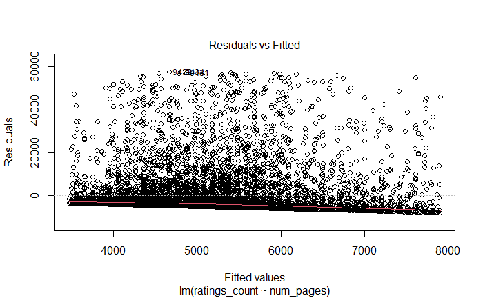

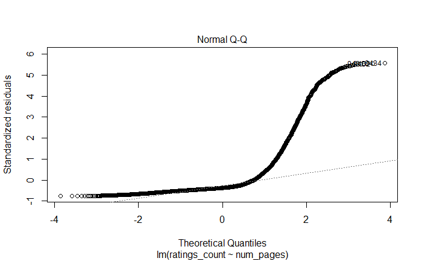

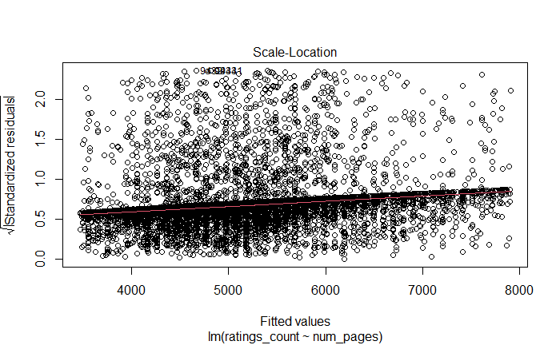

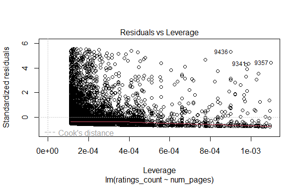

```r
plot(model)
```

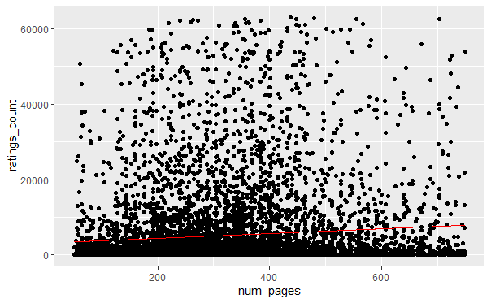

```r
data1 <- trimmed_books_v2 %>%
  add_predictions(model)

data1 %>%
  ggplot(aes(x = num_pages)) +
  geom_point(aes(y = ratings_count)) +
  geom_line(aes(y = pred), col = "red")
```

```r
trimmed_books_v2 %>%
summarise(skewness = skewness(ratings_count, type = 1))
```

| skewness |
| --- |
| 3.108315 |

The data is highly right skewed. In this case we should either look at the median as our stat, or look at standardising the data.

```r
summary(trimmed_books_v2)
```

```
    title             authors          average_rating     isbn13          language_code
 Length:8943        Length:8943        Min.   :2.400   Length:8943        eng    :7163
 Class :character   Class :character   1st Qu.:3.770   Class :character   en-US  :1200
 Mode  :character   Mode  :character   Median :3.940   Mode  :character   en-GB  : 190
                                       Mean   :3.928                      spa    : 161
                                       3rd Qu.:4.110                      fre    :  87
                                       Max.   :4.910                      ger    :  49
                                                                          (Other):  93
   num_pages     ratings_count   text_reviews_count publication_date      publisher
 Min.   : 51.0   Min.   :   10   Min.   :   0.0     Min.   :1900-01-01   Length:8943
 1st Qu.:208.0   1st Qu.:  165   1st Qu.:  12.0     1st Qu.:1998-06-04   Class :character
 Median :300.0   Median :  859   Median :  52.0     Median :2003-02-04   Mode  :character
 Mean   :316.5   Mean   : 5155   Mean   : 234.3     Mean   :2000-08-05
 3rd Qu.:400.0   3rd Qu.: 4412   3rd Qu.: 214.0     3rd Qu.:2005-10-01
 Max.   :750.0   Max.   :62954   Max.   :5699.0     Max.   :2020-03-31

 publication_year
 Min.   :1900
 1st Qu.:1998
 Median :2003
 Mean   :2000
 3rd Qu.:2005
 Max.   :2020
```

num_pages now ranges from 51-750.

Use this to add book range categories:

```r
trimmed_books_v2_with_range <- trimmed_books_v2 %>%
  mutate(page_range = case_when(
      num_pages <= 150 ~ "51-150",
      num_pages <= 250 ~ "151-250",
      num_pages <= 350 ~ "251-350",
      num_pages <= 450 ~ "351-450",
      num_pages <= 550 ~ "451-550",
      num_pages <= 650 ~ "551-650",
      num_pages <= 750 ~ "651-750"
  )) %>%
  mutate(page_range = factor(page_range,
                             levels = c("51-150",
                                        "151-250",
                                        "251-350",
                                        "351-450",
                                        "451-550",
                                        "551-650",
                                        "651-750")))
```

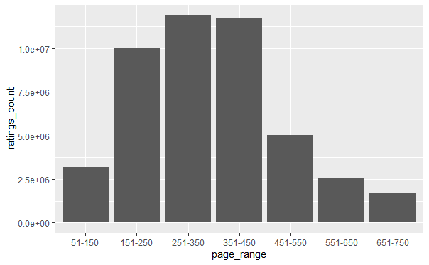

```r
trimmed_books_v2_with_range %>%
  ggplot(aes(x = page_range, y = ratings_count)) +
  geom_col()
```

```r
# writing clean data

trimmed_books_v2_with_range %>%  write.csv("books_cleaned.csv")
```

```r
(trimmed_v2_range_summary <- trimmed_books_v2_with_range %>%
  group_by(page_range) %>%
  summarise(median_ratings_count = median(ratings_count),
            num_books = n()))
```

| page_range | median_ratings_count | num_books |
| --- | --- | --- |
| 51-150 | 415.5 | 1006 |
| 151-250 | 647.0 | 2302 |
| 251-350 | 1120.5 | 2324 |
| 351-450 | 1234.0 | 1797 |
| 451-550 | 1119.0 | 779 |
| 551-650 | 872.0 | 478 |
| 651-750 | 925.0 | 257 |

```r
recent_publications <- c(2010, 2011, 2012, 2013, 2014)
```

```r
top_5_years_v2 <- trimmed_books_v2_with_range %>%
  group_by(publication_year) %>%
  summarise(num_books = n()) %>%
  arrange(desc(num_books)) %>%
  head(5)
```

```r
(trimmed_v2_range_summary_two <- trimmed_books_v2_with_range %>%
  filter(publication_year %in% top_5_years_v2$publication_year) %>%
  group_by(page_range, publication_year) %>%
  summarise(median_ratings_count = median(ratings_count),
            num_books = n()))
```

| page_range | publication_year | median_ratings_count | num_books |
| --- | --- | --- | --- |
| 51-150 | 2002 | 433.0 | 76 |
| 51-150 | 2003 | 403.0 | 81 |
| 51-150 | 2004 | 380.0 | 94 |
| 51-150 | 2005 | 379.0 | 85 |
| 51-150 | 2006 | 659.0 | 147 |
| 151-250 | 2002 | 486.0 | 152 |
| 151-250 | 2003 | 814.5 | 172 |
| 151-250 | 2004 | 821.0 | 223 |
| 151-250 | 2005 | 523.0 | 271 |
| 151-250 | 2006 | 841.5 | 328 |

[output cut: 25 more lines]

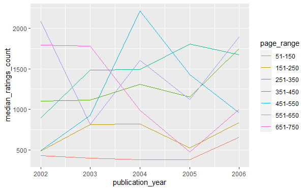

```r
trimmed_v2_range_summary_two %>%
  ggplot(aes(x = publication_year, y = median_ratings_count,
             colour = page_range)) +
  geom_line()
```

## Percentage of representation in dataset for each page range grouping

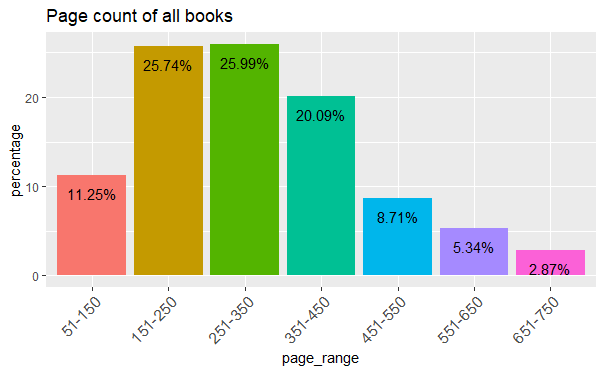

```r
total_books_v2 <- nrow(trimmed_books_v2_with_range)

(v2_page_range_overall <- trimmed_books_v2_with_range %>%
  group_by(page_range) %>%
  summarise(num_books = n()) %>%
  mutate(percentage = (num_books / total_books_v2) * 100) %>%
  ggplot(aes(x = page_range, y = percentage,
             fill = page_range)) +
  geom_col() +
  geom_text(aes(label = paste0(round(percentage, 2), "%")),
            vjust = 2) +
  labs(title = "Page count of all books") +
  theme(axis.text.x = element_text(size = 12, angle = 45, hjust = 1)) +
  guides(fill = FALSE))
```

## Top 500 books based on review count

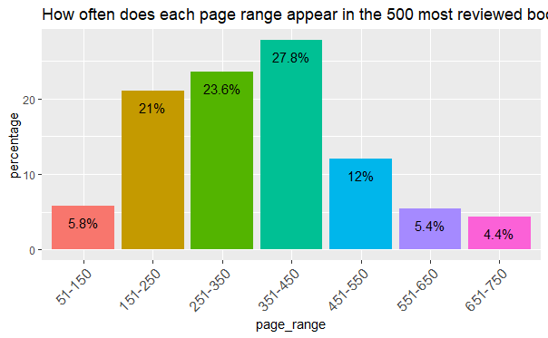

```r
(v2_page_range_top_500_review_count <- trimmed_books_v2_with_range %>%
  arrange(desc(ratings_count)) %>%
  head(500) %>%
  group_by(page_range) %>%
  summarise(num_books = n()) %>%
  mutate(percentage = (num_books / 500) * 100) %>%
  ungroup() %>%
  ggplot(aes(x = page_range, y = percentage, fill = page_range)) +
  geom_col() +
  geom_text(aes(label = paste0(round(percentage, 2), "%")),
            vjust = 2) +
  labs(title = "How often does each page range appear in the 500 most reviewed books?") +
  theme(axis.text.x = element_text(size = 12, angle = 45, hjust = 1)) +
  guides(fill = FALSE))
```

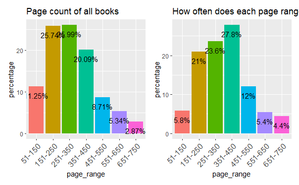

```r
#pasting both graphs together for side by side view
v2_page_range_overall + v2_page_range_top_500_review_count
```

## Top 500 books based on average rating

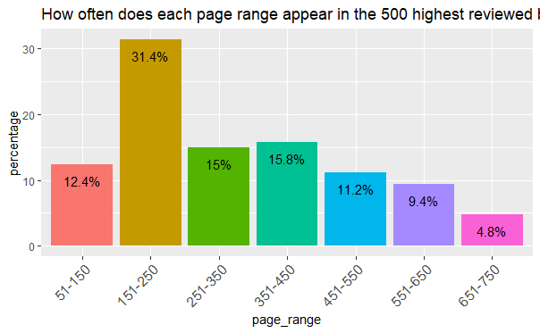

```r
(v2_page_range_top_500_avg_rating <- trimmed_books_v2_with_range %>%
  arrange(desc(average_rating)) %>%
  head(500) %>%
  group_by(page_range) %>%
  summarise(num_books = n()) %>%
  mutate(percentage = (num_books / 500) * 100) %>%
  ungroup() %>%
  ggplot(aes(x = page_range, y = percentage, fill = page_range)) +
  geom_col() +
  geom_text(aes(label = paste0(round(percentage, 2), "%")),
            vjust = 2) +
  labs(title = "How often does each page range appear in the 500 highest reviewed books?") +
  theme(axis.text.x = element_text(size = 12, angle = 45, hjust = 1)) +
  guides(fill = FALSE))
```

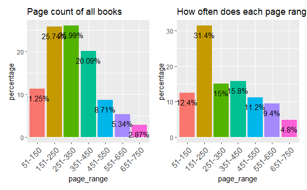

```r
#pasting both graphs together for side by side view
v2_page_range_overall + v2_page_range_top_500_avg_rating
```

## Recreating above graphs with untrimmed dataset

We are no longer looking for a statistion (e.g. mean or median) so removing outliers may not be necessary:

```r
summary(books_cleaned_v2)
```

```
    title             authors          average_rating     isbn13          language_code
 Length:11041       Length:11041       Min.   :1.000   Length:11041       eng    :8844
 Class :character   Class :character   1st Qu.:3.780   Class :character   en-US  :1408
 Mode  :character   Mode  :character   Median :3.960   Mode  :character   en-GB  : 214
                                       Mean   :3.943                      spa    : 212
                                       3rd Qu.:4.140                      fre    : 139
                                       Max.   :5.000                      ger    :  96
                                                                          (Other): 128
   num_pages      ratings_count     text_reviews_count publication_date      publisher
 Min.   :   0.0   Min.   :      1   Min.   :    0      Min.   :1900-01-01   Length:11041
 1st Qu.: 194.0   1st Qu.:    110   1st Qu.:    9      1st Qu.:1998-08-01   Class :character
 Median : 300.0   Median :    766   Median :   48      Median :2003-03-01   Mode  :character
 Mean   : 336.7   Mean   :  18075   Mean   :  546      Mean   :2000-09-03
 3rd Qu.: 416.0   3rd Qu.:   5061   3rd Qu.:  241      3rd Qu.:2005-10-01
 Max.   :6576.0   Max.   :4597666   Max.   :94265      Max.   :2020-03-31

 publication_year
 Min.   :1900
 1st Qu.:1998
 Median :2003
 Mean   :2000
 3rd Qu.:2005
 Max.   :2020
```

The num_pages range from 0 to 6576. We remove the top and bottom 5% for the same reasons as before: to remove audio books and anthologies. We can use the previously created trimmed_books_v1 and add the categorical page range variable.

```r
trimmed_books_v1
```

|  | title | authors | average_rating | isbn13 | language_code | num_pages | ratings_count | text_reviews_count | publication_date | publisher | publication_year |
| --- | --- | --- | --- | --- | --- | --- | --- | --- | --- | --- | --- |
| 553 | A Clockwork Orange (Stage Play) | Anthony Burgess | 3.84 | 9780413735904 | eng | 51 | 28 | 2 | 2017-03-10 | Methuen Drama | 2017 |
| 554 | The Portrait of Dorian Gray | Oscar Wilde/Elizabeth Gray | 4.08 | 9781842161906 | eng | 51 | 85 | 2 | 1999-10-10 | Express Publishing | 1999 |
| 555 | The Facts in the Case of the Departure of Miss Finch | Neil Gaiman/Michael Zulli | 3.54 | 9781593076672 | eng | 51 | 2038 | 198 | 2008-04-01 | Dark Horse Books | 2008 |
| 556 | The SantaLand Diaries and Season's Greetings | David Sedaris/Joe Mantello | 4.18 | 9780822216315 | eng | 54 | 584 | 34 | 1998-12-01 | Dramatists Play Service | 1998 |
| 557 | And Still I Rise | Maya Angelou/Linda Sunshine/Diego Rivera | 4.42 | 9780375505966 | eng | 54 | 3720 | 240 | 2001-08-07 | Random House | 2001 |
| 558 | Hamlet (Oxford Bookworms Library: Stage 2) | Alistair McCallum/William Shakespeare | 3.89 | 9780194232203 | eng | 54 | 164 | 6 | 2005-10-01 | Oxford University Press USA | 2005 |
| 559 | Bill Bryson's African Diary | Bill Bryson | 3.44 | 9780767915069 | eng | 55 | 7270 | 499 | 2002-12-03 | Broadway Books | 2002 |
| 560 | Brokeback Mountain | Annie Proulx | 3.94 | 9780743271325 | eng | 55 | 24985 | 1751 | 2005-12-02 | Scribner | 2005 |
| 561 | Lotta on Troublemaker Street | Astrid Lindgren/Robin Preiss Glasser | 3.98 | 9780689846731 | eng | 55 | 1429 | 24 | 2001-10-01 | Aladdin Paperbacks | 2001 |
| 562 | Kill Your Boyfriend | Grant Morrison/Philip Bond/D'Israeli/Daniel Vozzo | 3.57 | 9781563894534 | en-US | 55 | 1269 | 66 | 1998-12-31 | DC Comics Vertigo | 1998 |

[output cut: 990 more lines]

```r
trimmed_books_v1_with_range <- trimmed_books_v1 %>%
  mutate(page_range = case_when(
      num_pages <= 150 ~ "51-150",
      num_pages <= 250 ~ "151-250",
      num_pages <= 350 ~ "251-350",
      num_pages <= 450 ~ "351-450",
      num_pages <= 550 ~ "451-550",
      num_pages <= 650 ~ "551-650",
      num_pages <= 750 ~ "651-750"
  )) %>%
  mutate(page_range = factor(page_range,
                             levels = c("51-150",
                                        "151-250",
                                        "251-350",
                                        "351-450",
                                        "451-550",
                                        "551-650",
                                        "651-750")))
```

## Percentage of representation in dataset for each page range grouping (where ratings count has not been trimmed)

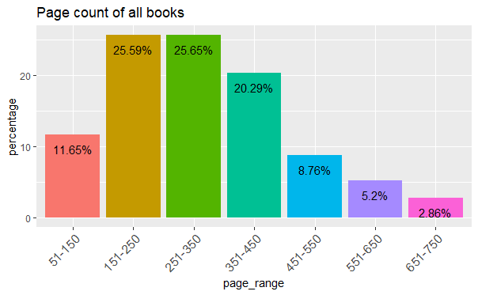

```r
total_books_v1 <- nrow(trimmed_books_v1_with_range)

(v1_page_range_overall <- trimmed_books_v1_with_range %>%
  group_by(page_range) %>%
  summarise(num_books = n()) %>%
  mutate(percentage = (num_books / total_books_v1) * 100) %>%
  ggplot(aes(x = page_range, y = percentage,
             fill = page_range)) +
  geom_col() +
  geom_text(aes(label = paste0(round(percentage, 2), "%")),
            vjust = 2) +
  labs(title = "Page count of all books") +
  theme(axis.text.x = element_text(size = 12, angle = 45, hjust = 1)) +
  guides(fill = FALSE))
```

## Top 500 books based on review count

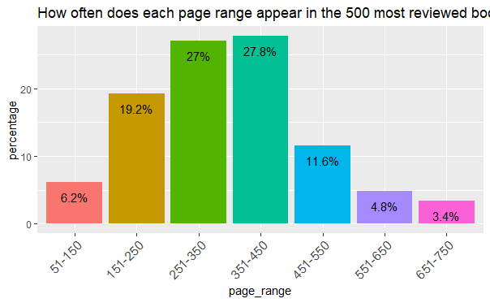

```r
(v1_page_range_top_500_review_count <- trimmed_books_v1_with_range %>%
  arrange(desc(ratings_count)) %>%
  head(500) %>%
  group_by(page_range) %>%
  summarise(num_books = n()) %>%
  mutate(percentage = (num_books / 500) * 100) %>%
  ungroup() %>%
  ggplot(aes(x = page_range, y = percentage, fill = page_range)) +
  geom_col() +
  geom_text(aes(label = paste0(round(percentage, 2), "%")),
            vjust = 2) +
  labs(title = "How often does each page range appear in the 500 most reviewed books?") +
  theme(axis.text.x = element_text(size = 12, angle = 45, hjust = 1)) +
  guides(fill = FALSE))
```

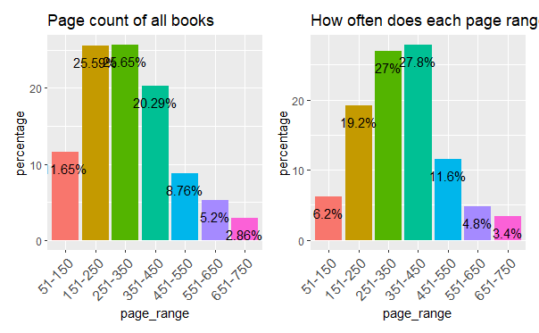

```r
#pasting both graphs together for side by side view
v1_page_range_overall + v1_page_range_top_500_review_count
```

## Top 500 untrimmed books based on average rating

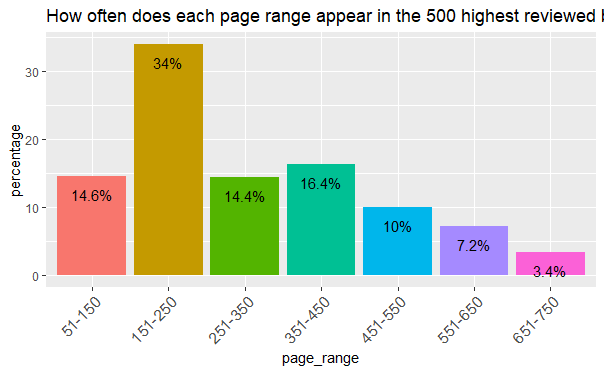

```r
(v1_page_range_top_500_avg_rating <- trimmed_books_v1_with_range %>%
  arrange(desc(average_rating)) %>%
  head(500) %>%
  group_by(page_range) %>%
  summarise(num_books = n()) %>%
  mutate(percentage = (num_books / 500) * 100) %>%
  ungroup() %>%
  ggplot(aes(x = page_range, y = percentage, fill = page_range)) +
  geom_col() +
  geom_text(aes(label = paste0(round(percentage, 2), "%")),
            vjust = 2) +
  labs(title = "How often does each page range appear in the 500 highest reviewed books?") +
  theme(axis.text.x = element_text(size = 12, angle = 45, hjust = 1)) +
  guides(fill = FALSE))
```

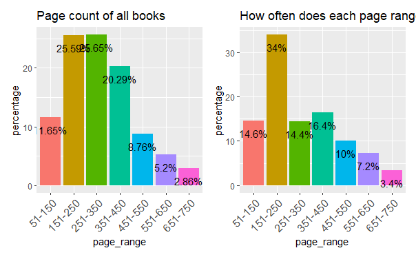

```r
#pasting both graphs together for side by side view
v1_page_range_overall + v1_page_range_top_500_avg_rating
```